# Costa Rica: Understanding the Complexities of Poverty

The goals today are twofold. In line with the Kaggle instructions, I will first try to predict the poverty status variable (`Target`) as best as possible. But perhaps more importantly, I will try to understand exactly what explains poverty in this dataset by reducing and simplifying a model into a coherent form. Exploratory analysis involves not only understanding data, but also understanding the models that one prescribes to the data.

## Setup

Load some of my favorite packages, read some csv’s.

```r
library(tidyverse)
library(rpart)
library(rpart.plot)
library(nnet)
library(randomForest)
library(xgboost)
library(caret)
library(pROC)

costa_rica <- read_csv("data/train.csv")
data_dict  <- read_csv("data/data-dict.csv")
```

## Basic EDA

This is a fairly wide dataset (dimensions: 9557 x 143), which makes it difficult and time consuming to manually understand each feature. For now, I will check for `NA`’s and other oddities. [rOpenSsci’s](https://ropensci.org/) `visdat` package makes this easy. The plot below is essentially a picture of the dataset at a 10,000 foot view.

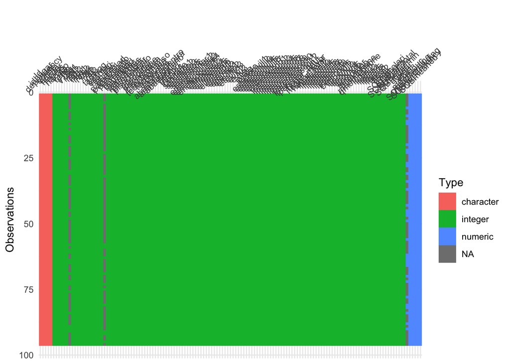

```r
visdat::vis_dat(costa_rica %>% sample_frac(.01))
```

A couple of columns have a lot of `NA`’s. It’s also nice to see the distribution of column types (mostly integers, a few doubles and a few characters). This is a good sanity check because the data dictionary suggests that many of the columns are countable measures.

But the plot above makes it hard to read the column names. What exactly is in here? Below is a glimpse of the data dictionary.

```
## # A tibble: 10 x 2
##    col_name description
##    <chr>    <chr>
##  1 v2a1     Monthly rent payment
##  2 hacdor   =1 Overcrowding by bedrooms
##  3 rooms    number of all rooms in the house
##  4 hacapo   =1 Overcrowding by rooms
##  5 v14a     =1 has bathroom in the household
##  6 refrig   =1 if the household has refrigerator
##  7 v18q     owns a tablet
##  8 v18q1    number of tablets household owns
##  9 r4h1     Males younger than 12 years of age
## 10 r4h2     Males 12 years of age and older
```

Pretty interesting stuff. There are a handful of features pertaining to things like education, housing quality, and access to technology. The column names are in Spanish, so I will be referring back to the data dictionary often. Each row in the dataset represents a person, so the `Target` column is that person’s income status. The Kaggle problem, however, wants a prediction for each household (`idhogar`), so I will have to do a little transformation.

And what about the `Target` variable? Kaggle notes that there are four income levels.

- 1: Extreme Poverty
- 2: Moderate Poverty
- 3: Vulnerable Households
- 4: Non Vulnerable Households

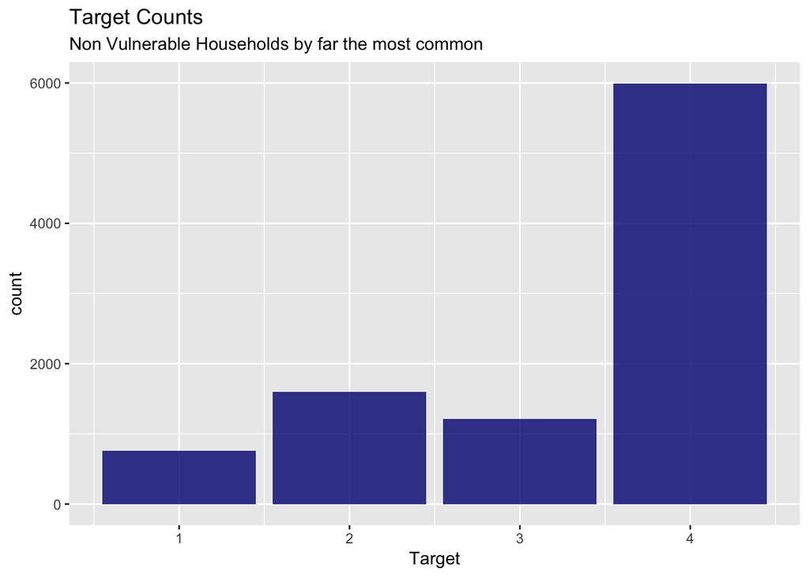

```r
ggplot(costa_rica, aes(x = Target)) +
  geom_bar(fill = "navy", alpha = .8) +
  ggtitle("Target Counts",
          subtitle = "Non Vulnerable Households by far the most common")
```

Because there are four levels, I will need to approach this as a [multinomial classification](https://en.wikipedia.org/wiki/Multiclass_classification) problem, which is unfortunately harder to interpret than binary classification or regression. It’s also worth noting that the `Target` variable is skewed, with the count of level **4**’s dwarfing the others. This is thankfully a good thing for the people of Costa Rica, but it might make the analysis again more difficult. In machine learning jargon this is known as an imbalanced dataset. There are ways to ameliorate this issue, but I might not need to examine them just yet.

## Data Prep

```r
# re-assign Targets to appropriate head of household Targets ----
parent_targets <-
  costa_rica %>%
  filter(parentesco1 == 1) %>%
  dplyr::select(idhogar, hh_Target = Target)

costa_rica_adj <-
  costa_rica %>%
  left_join(parent_targets) %>%
  mutate(
    Target = if_else(is.na(hh_Target), Target, hh_Target)
  )

# remove the annoying variables for now ----
no_nas <- function(x) {
  !any(is.na(x))
}

costa_rica_adj<-
  costa_rica_adj %>%
  dplyr::select(-Id, -idhogar, -hh_Target) %>%
  dplyr::select_if(is.numeric) %>%
  dplyr::select_if(no_nas) %>%
  dplyr::select_if(.predicate = funs(sd(.) > 0))
```

The Kaggle instructions call for one prediction per household. So I converted every non head of household’s `Target` level to its corresponding parent `Target` (`parentesco1 == 1`). For simplicity, I also decided to ignore any column with an `NA` and any non-numeric column. This reduced the dataset’s dimensions to 9557 x 132.

## Machine Learning Models: First Pass

For a classification problem like this with many reasonable features (and for which I have little domain knowledge), I like to throw a random forest at it and see what sticks. [This post](https://medium.com/rants-on-machine-learning/the-unreasonable-effectiveness-of-random-forests-f33c3ce28883) on Medium gives a good background of why this is a fair choice. Not to mention [this paper](http://lowrank.net/nikos/pubs/empirical.pdf) referenced in the article (and written by very smart people at Cornell).

```r
# split up train and test ----
train_rows <- sample(x = 1:nrow(costa_rica_adj), size = 0.8 * nrow(costa_rica_adj))

train <-
  costa_rica_adj %>%
  filter(
    row_number() %in% train_rows
  )

test <-
  costa_rica_adj %>%
  filter(
    !(row_number() %in% train_rows)
  )

set.seed(1)
rfmod <- randomForest(factor(Target) ~ ., data = train, ntree = 50, importance = T)
```

After splitting the cleaned up dataset into `train` and `test` data frames, I built a random forest with 50 trees. The plot below, however, suggests I might not even need that many.

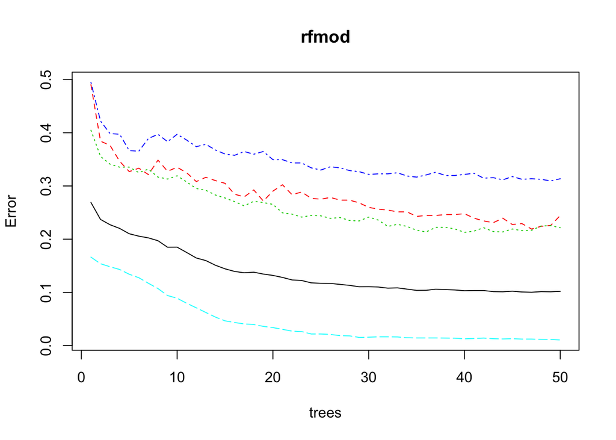

```r
plot(rfmod)
```

Each of the lines above represent the relationship between accuracy and the number of trees. The dashed and dotted ones represent each of the `Target` levels (red = **1**, green = **2**, blue = **3**, light blue = **4**), while the black line represents the overall model accuracy. I’ve also got the output of the confusion matrix below.

```r
rfpreds <- predict(rfmod, newdata = test) %>% as.character() %>% as.numeric()

cm <- caret::confusionMatrix(table(rfpreds, actual = test$Target))

cm$table %>% ftable() %>% pander::pander()
```

|  | actual | 1 | 2 | 3 | 4 |
| --- | --- | --- | --- | --- | --- |
| rfpreds |  |  |  |  |  |
| 1 |  | 140 | 0 | 4 | 0 |
| 2 |  | 4 | 250 | 4 | 3 |
| 3 |  | 2 | 2 | 175 | 6 |
| 4 |  | 39 | 51 | 62 | 1170 |

```r
cm$byClass %>% data.frame() %>% dplyr::select(Sensitivity, Specificity) %>% t() %>% knitr::kable()
```

|  | Class: 1 | Class: 2 | Class: 3 | Class: 4 |
| --- | --- | --- | --- | --- |
| Sensitivity | 0.7567568 | 0.8250825 | 0.7142857 | 0.9923664 |
| Specificity | 0.9976838 | 0.9931635 | 0.9940012 | 0.7926330 |

A couple of points to emphasize here.

## Machine Learning Validation

This is the [bike shed](https://en.wikipedia.org/wiki/Law_of_triviality) portion of the report. But I will say, the final graph is a big argument for ensemble methods and/or boosting.

How do other models perform on this data? I decided to explore a few others that natively support multinomial classification in R.

- Decision Trees from the `rpart` package
- Multinomial Regression from the `nnet` package
- Random Forests from the `randomForest` package
- eXtreme Gradient Boosted Trees from the `xgboost` package

The first two could be called “interpretable”, while the next two are pretty much black boxes. Comparing these models lets me quantify the tradeoffs of interpretability and predictive performance, which falls nicely in line with my other main goal today.

Below is the output of a 30-fold cross validation for each of the models above. Each time, I measured the [AUC](https://en.wikipedia.org/wiki/Receiver_operating_characteristic#Area_under_the_curve) by comparing the individual fold’s predictions to the individual fold’s holdout set. The AUC has a slightly different interpretation [in the multiclass scenario](https://stats.stackexchange.com/questions/2151/how-to-plot-roc-curves-in-multiclass-classification), but this is a fact I will gloss over for now. If you are interested in the simulation code, it is here.

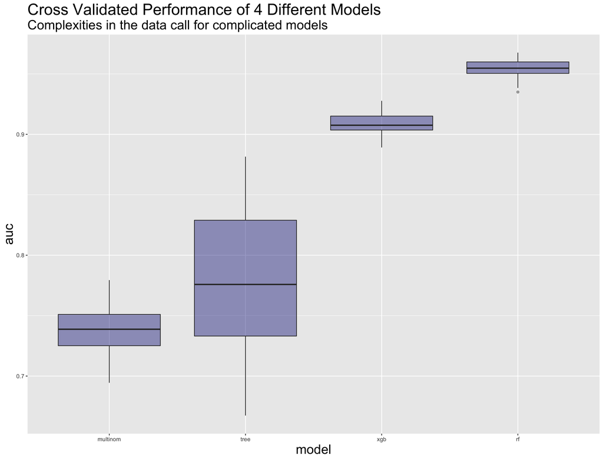

```r
knitr::include_graphics("pics/cv-aucs.png")
```

In short, we see that the random forests take the cake. And the average difference between the two baseline models and the two complicated models is somewhere in the realm of .15 AUC points. Which is quite a lot, considering that the practical domain of AUC’s is between .5 and 1.0. By using a simpler model, I would be potentially sacrificing a lot of classification effectiveness.

## Variable Importance, Model Simplification

This is not to say that there is no hope of understanding what the models are doing. Both `randomForest` and `xgboost` have built in methods to assess variable importance (which in my humble opinion is one of the most important areas of machine learning right now). Because both algorithms involve many iterations / samples, they are able to store the average marginal impact a specific column has on classification accuracy. This results in a big-picture ranking of columns from “most important” to “least important”.

The plot below is the ranking done by the original `randomForest` model.

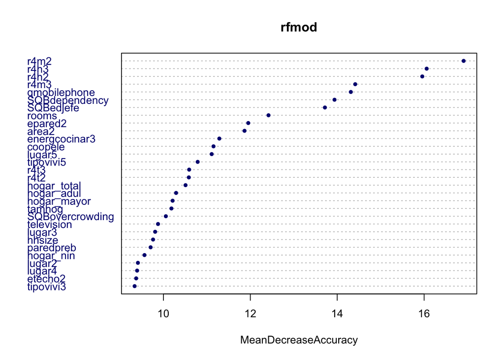

```r
varImpPlot(rfmod, type = 1, pch = 20, col = "navy", cex = .9)
```

The most important predictors require a consultation with the data dictionary. Here are the top 10.

```r
top10_cols <-
  importance(rfmod) %>%
  data.frame() %>%
  rownames_to_column(var = "col_name") %>%
  arrange(desc(MeanDecreaseAccuracy)) %>%
  head(10)

top10_cols %>%
  inner_join(data_dict) %>%
  dplyr::select(col_name, description) %>%
  knitr::kable()
```

| col_name | description |
| --- | --- |
| r4m2 | Females 12 years of age and older |
| r4h3 | Total males in the household |
| r4h2 | Males 12 years of age and older |
| r4m3 | Total females in the household |
| qmobilephone | # of mobile phones |
| SQBdependency | dependency squared |
| SQBedjefe | edjefe squared |
| rooms | number of all rooms in the house |
| epared2 | =1 if walls are regular |
| area2 | =2 zona rural |

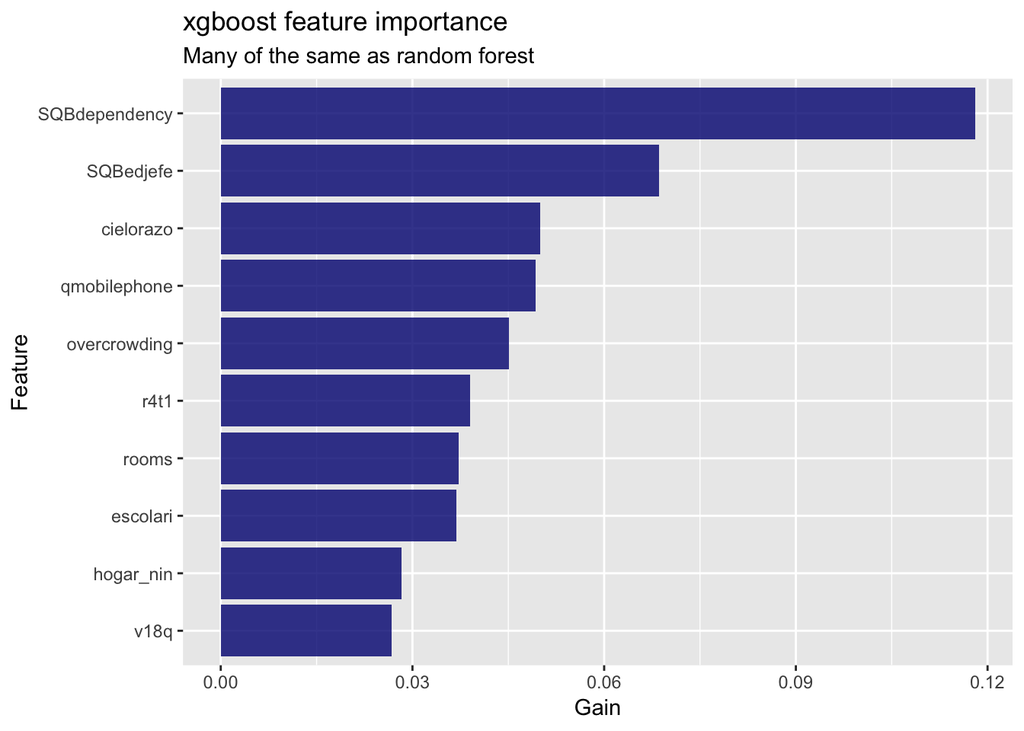

```r
xgb_params <- list("objective" = "multi:softprob",
                   "eval_metric" = "mlogloss",
                   "num_class" = 4)

xgbmod <-
  xgboost(
    xgb.DMatrix(
      as.matrix(train %>% dplyr::select(-Target)),
      label = (train %>% pull(Target) -1 )
    ),
    nrounds = 20, verbose = 0,
    params = xgb_params)

xgb_top10_cols <-
  xgb.importance(
    feature_names = colnames(train %>% dplyr::select(-Target)),
    model = xgbmod) %>%
    head(10)

ggplot(xgb_top10_cols,
       aes(x = reorder(Feature, Gain), y = Gain)) +
  geom_col(fill = "navy", alpha = .8) +
  xlab("Feature") +
  coord_flip() +
  ggtitle("xgboost feature importance",
          subtitle = "Many of the same as random forest")
```

Again we see similar results, although not exactly the same column names. Could this be because several of the columns are related to each other?

Here’s a thought. What if we take the top 30 features from both models, find the intersection between them, and then build a final model off of that? How much worse will it perform than the original random forest? The table below are the features that are ranked in the top 30 of both models.

```r
overlapping_vars <-
  importance(rfmod) %>%
  data.frame() %>%
  rownames_to_column(var = "col_name") %>%
  arrange(desc(MeanDecreaseAccuracy)) %>%
  head(30) %>%
inner_join(
  xgb.importance(
    feature_names = colnames(train %>% dplyr::select(-Target)),
    model = xgbmod) %>%
    head(30),
  by = c("col_name" = "Feature")
)

overlapping_vars %>% knitr::kable()
```

| col_name | X1 | X2 | X3 | X4 | MeanDecreaseAccuracy | MeanDecreaseGini | Gain | Cover | Frequency |
| --- | --- | --- | --- | --- | --- | --- | --- | --- | --- |
| r4m2 | 9.628694 | 14.105967 | 11.366769 | 13.604760 | 16.909892 | 63.97986 | 0.0200651 | 0.0190437 | 0.0262983 |
| r4h3 | 9.733818 | 11.810869 | 12.256977 | 11.398860 | 16.059138 | 74.01528 | 0.0172916 | 0.0108548 | 0.0193076 |
| r4h2 | 10.590418 | 9.295075 | 11.163848 | 12.146612 | 15.957965 | 76.04800 | 0.0237823 | 0.0152531 | 0.0309587 |
| r4m3 | 8.671424 | 11.740669 | 11.284760 | 11.669345 | 14.414437 | 76.71449 | 0.0155920 | 0.0170677 | 0.0206391 |
| qmobilephone | 11.279476 | 13.606054 | 13.711600 | 12.739744 | 14.313441 | 124.15035 | 0.0493333 | 0.0604272 | 0.0456059 |
| SQBdependency | 11.529520 | 13.184547 | 12.529222 | 13.619827 | 13.937758 | 170.50499 | 0.1180565 | 0.0903189 | 0.0509321 |
| SQBedjefe | 11.757979 | 12.782925 | 12.427012 | 12.091790 | 13.717005 | 130.92435 | 0.0685659 | 0.0734941 | 0.0652463 |
| rooms | 9.944732 | 10.090402 | 11.243518 | 11.014268 | 12.418413 | 99.16427 | 0.0372866 | 0.0481455 | 0.0539281 |
| lugar5 | 7.408216 | 6.786902 | 6.661766 | 9.027905 | 11.110217 | 28.77449 | 0.0102836 | 0.0062871 | 0.0129827 |
| r4t2 | 10.225129 | 7.788435 | 10.935723 | 9.526116 | 10.584308 | 78.01149 | 0.0252829 | 0.0290824 | 0.0292943 |
| hogar_adul | 8.957040 | 7.888464 | 8.832958 | 10.069971 | 10.290742 | 67.61128 | 0.0191921 | 0.0199474 | 0.0153129 |
| hogar_nin | 7.602054 | 8.005535 | 8.893486 | 9.547035 | 9.563535 | 83.72586 | 0.0282432 | 0.0265380 | 0.0256325 |
| tipovivi3 | 5.281788 | 6.861744 | 9.320640 | 7.980144 | 9.336172 | 30.40586 | 0.0100989 | 0.0105999 | 0.0109854 |

There are 13 of them. Now train an updated random forest with 13 / 131 = 10% of its original features.

```r
rfmod_simple <- randomForest(factor(Target) ~ ., data = train %>% dplyr::select(overlapping_vars$col_name, Target), ntree = 50)

rfpreds_simple <- predict(rfmod_simple, newdata = test) %>% as.character() %>% as.numeric()

cm2 <- caret::confusionMatrix(table(rfpreds_simple, actual = test$Target))

cm2$table %>% ftable() %>% pander::pander()
```

|  | actual | 1 | 2 | 3 | 4 |
| --- | --- | --- | --- | --- | --- |
| rfpreds_simple |  |  |  |  |  |
| 1 |  | 143 | 2 | 3 | 6 |
| 2 |  | 4 | 245 | 7 | 7 |
| 3 |  | 1 | 2 | 163 | 9 |
| 4 |  | 37 | 54 | 72 | 1157 |

```r
cm2$byClass %>% data.frame() %>% dplyr::select(Sensitivity, Specificity) %>% t() %>% knitr::kable()
```

|  | Class: 1 | Class: 2 | Class: 3 | Class: 4 |
| --- | --- | --- | --- | --- |
| Sensitivity | 0.7729730 | 0.8085809 | 0.6653061 | 0.9813401 |
| Specificity | 0.9936306 | 0.9888129 | 0.9928014 | 0.7776262 |

For comparison, here’s the results against the original

```r
cm$table %>% ftable() %>% pander::pander()
```

|  | actual | 1 | 2 | 3 | 4 |
| --- | --- | --- | --- | --- | --- |
| rfpreds |  |  |  |  |  |
| 1 |  | 140 | 0 | 4 | 0 |
| 2 |  | 4 | 250 | 4 | 3 |
| 3 |  | 2 | 2 | 175 | 6 |
| 4 |  | 39 | 51 | 62 | 1170 |

```r
cm$byClass %>% data.frame() %>% dplyr::select(Sensitivity, Specificity) %>% t() %>% knitr::kable()
```

|  | Class: 1 | Class: 2 | Class: 3 | Class: 4 |
| --- | --- | --- | --- | --- |
| Sensitivity | 0.7567568 | 0.8250825 | 0.7142857 | 0.9923664 |
| Specificity | 0.9976838 | 0.9931635 | 0.9940012 | 0.7926330 |

And if you’re curious about AUC’s, the original random Forest with 50 trees had an AUC of 0.9558009 and the reduced model has an AUC of 0.9350787 against the same test set. Pretty nice. Interpretable dimensionality reduction (a hack) with no PCA.

## Conclusions and Next Steps

Poverty in this dataset is primarily described by

1. the number of working-age people
2. the access to electricity
3. the average educational level

of the member’s household. Although this result is not exactly surprising, I think it’s important to verify the output of the models with intuition when possible, especially considering the importance of the issue here.

The most interesting avenue for further research into this dataset, in my opinion, is to investigate the difficult-to-classify cases and see if there are commonalities among them. If this could be determined from within the data, one could engineer clever new features to help train models. Other than that, I would like to learn more about the culture and political background of Costa Rica, along with the critical issues experts in the region deem important to reducing poverty.

I’ve had a lot of fun working on this problem and would like to thank the Kaggle community for putting time and energy into questions like these.